[figure not shown]

# Use `%matplotlib widget` or `%matplotlib notebook` for interactive plots when notebook is running locally on your computer

```python
import sys
# interactive matplotlib doesn't work on google colab, so fall back to inline
if 'miniconda' not in sys.executable:
    %matplotlib inline
    !{sys.executable} -m pip install --force https://github.com/chengs/tqdm/archive/colab.zip
    !{sys.executable} -m pip install sigpy h5py
    ! git clone https://github.com/CARDIAL-nyu/cmr-playground
    %cd cmr-playground/golden_angle_sample
else:
    %matplotlib notebook
```

```python
from IPython.display import Javascript
import matplotlib.pyplot as plt
import matplotlib as mpl
import numpy as np
import scipy as sp
import scipy.signal
import scipy.io
import seaborn as sns
import sigpy
import sigpy.plot

plt.style.use('fivethirtyeight')
five_thirty_eight = [
"#30a2da",
"#fc4f30",
"#e5ae38",
"#6d904f",
"#8b8b8b",
]
sns.set_palette(five_thirty_eight, color_codes=True)
sns.set_color_codes()

mpl.rcParams['axes.grid'] = False
```

# Load in a sample OCMR reconstruction

```python
slice_mat = scipy.io.loadmat('output_slice1_us_0156_pt_1_5T_reshapeF_slice4.mat')
```

```python
# What's inside this container...
slice_mat.keys()
```

```
dict_keys(['__header__', '__version__', '__globals__', 'xHat', 'pOut', 'xHat_abs_norm'])
```

### Dimensions

- `n_ro`: number of samples in the readout direction
- `n_pe`: number of phase-encoding lines
- `n_frames`: number of frames in this cine

```python
n_ro, n_pe, n_frames = slice_mat['xHat_abs_norm'].shape
n_ro, n_pe, n_frames
```

```
(352, 134, 30)
```

### Create a square frame

- for ease, let's deal with square images by zero-filling the borders

```python
selected_frame = 0
square_cine = np.zeros((n_ro, n_ro))
square_cine[:,(n_ro-n_pe)//2:-(n_ro-n_pe)//2] = slice_mat['xHat_abs_norm'][...,selected_frame]
square_cine.shape
```

```
(352, 352)
```

### Visualize the frame we're dealing with

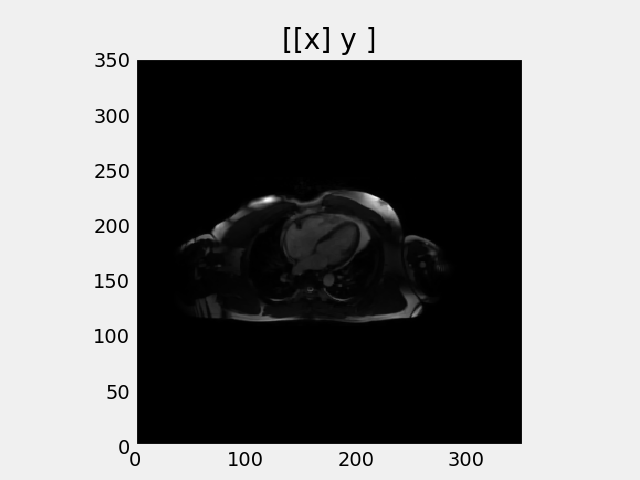

```
<sigpy.plot.ImagePlot at 0x7f513e885650>
```

```python
sigpy.plot.ImagePlot(square_cine, x=0, y=1)
```

# Helper functions

- `return_ga_traj` returns the tiny golden angle kspace trajectory

```python
def return_ga_traj(nX, ntviews, tiny_num=7):
    """Returns tiny golden angle trajectory and density compensation

    Parameters
    ----------
    nX : int
        number of readout points
    ntviews : int
        number of radial spokes/turns
    tiny_num : int
        type of golden angle, e.g. 7 for 7th tiny golden angle

    Returns
    -------
    traj : ndarray
        trajectory with shape (nX, ntviews)
    densitycomp : ndarray

    Reference
    ---------
    https://doi.org/10.1002/mrm.25831

    """
    golden_ratio = (np.sqrt(5.0) + 1.0) / 2.0
    golden_angle = np.pi / (golden_ratio + tiny_num - 1)

    radian = np.mod(np.arange(0, ntviews) * golden_angle, 2. * np.pi)
    rho = np.arange(-np.floor(nX / 2), np.floor(nX / 2)) + 0.5

    _sin = np.sin(radian)
    _cos = np.cos(radian)

    # Complex trajectory
    traj = np.stack(((rho[..., np.newaxis] * _sin[np.newaxis, ...]),
                     (rho[..., np.newaxis] * _cos[np.newaxis, ...])), axis=2)

    # Density Compensation
    densitycomp = np.sqrt(np.power(traj[...,0], 2) + np.power(traj[...,1], 2))
    densitycomp /= densitycomp.max()

    # Reshape into (n_spokes, n_readout, 2)
    traj = traj.transpose((1,0,2))

    # Reshape into (n_spokes, n_readout)
    densitycomp = densitycomp.transpose((1,0))

    return traj, densitycomp
```

### Create a radial trajectory based off of the nyquist rate

- nyquist criteria for radial trajectories is $\frac{\textrm{N}\pi}{2}$, where $\textrm{N}$ is the number of lines required for fully-sampled data in cartesian sampling. In this case, it is equal to `n_ro`.

```python
ntviews = int(np.pi*n_ro/2)

# Get the 7th tiny golden angle k-space trajectory and density compensation
traj, dc = return_ga_traj(nX=n_ro, ntviews=ntviews)

n_ro, ntviews, traj.shape, dc.shape
```

```
(352, 552, (552, 352, 2), (552, 352))
```

- Use the golden-angle radial trajectory and the non-uniform FFT operator to transform the image into non-cartesian k-space

```python
NUFFT = sigpy.linop.NUFFT(ishape=square_cine[np.newaxis,...].shape,
                          coord=traj)
# Apply the operator to transform the image into non-cartesian k-space
ksp_radial = NUFFT*square_cine[np.newaxis,...] # add a singleton dimension to the front to confirm with sigpy conventions
ksp_radial.shape
```

```
(1, 552, 352)
```

# Visualize the non-cartesian k-space data

- this would be similar to what we'd get out of an MRI machine that was scanning using a non-cartesian radial trajectory with a **single** coil
- if you look at the 2nd subplot below, you'll notice that non-cartesian k-space data that's acquired with the MRI machine does not fall nicely on a grid
- this is what makes the radial masks on fully-sampled cartesian data from the `RefineGAN` repository a little different than reality; with just the simple radial mask placed on top of fully sampled data, you're still using exact acquired data without any of the distortions that would've been introduced by interpolating acquired non-cartesian data onto a cartesian grid.

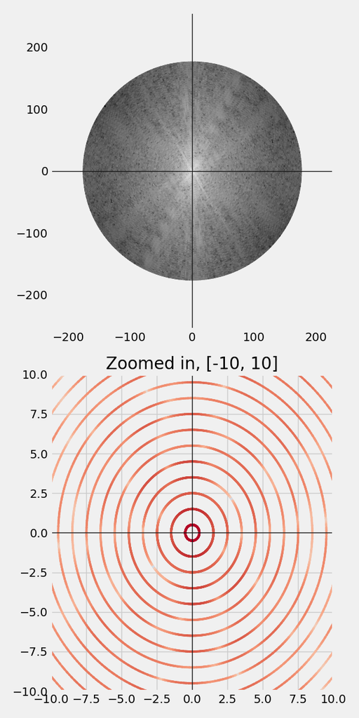

```python
# Change this to 10 or some other low number to better visualize the individual spokes
# Set to None if you want to see all the spokes
n_spokes_to_plot = None

f_spokes, ax_spokes = plt.subplots(nrows=2, ncols=1, figsize=(6,12))

ax_spokes[0].axhline(0, color='k', lw=1)
ax_spokes[0].axvline(0, color='k', lw=1)
ax_spokes[0].scatter(traj[:n_spokes_to_plot,:,0], traj[:n_spokes_to_plot,:,1],
                     s=3,
                     c=np.log(np.abs(ksp_radial[:,:n_spokes_to_plot,:])), cmap='gray')
ax_spokes[0].axis('equal')

ax_spokes[1].set_title('Zoomed in, [-10, 10]')
ax_spokes[1].axhline(0, color='k', lw=1)
ax_spokes[1].axvline(0, color='k', lw=1)
ax_spokes[1].scatter(traj[:n_spokes_to_plot,:,0], traj[:n_spokes_to_plot,:,1],
                     s=5,
                     c=np.log(np.abs(ksp_radial[:,:n_spokes_to_plot,:])), cmap='coolwarm')
ax_spokes[1].grid(True, which='major')

lim_max = 10
ax_spokes[1].set_xlim(-lim_max, lim_max)
ax_spokes[1].set_ylim(-lim_max, lim_max)

f_spokes.tight_layout()
```

# Reconstruct the image from the non-cartesian data

- since the data does not fall on a neat uniformly spaced grid that's required for typical `FFT` reconstruction, we need to use the adjoint operator of the non-uniform FFT (`NUFFT`) to go from non-cartesian k-space to image space

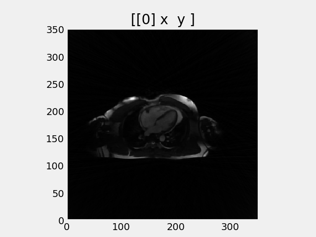

```
<sigpy.plot.ImagePlot at 0x7f513e4e4c90>
```

```python
# reconstruct the data by applying the non-uniform FFT operator on the density-compensated kspace data
back = NUFFT.H*(ksp_radial*dc)

# We can see what happens if we don't apply density-compensation to weigh down the oversampled low frequency data
# relative to the high frequency data --the image will be dominated by the oversampled low frequency data
back_no_density_compensation = NUFFT.H*ksp_radial

sigpy.plot.ImagePlot(back, x=1, y=2)
```

# Without density-compensation

- radial k-space data without density compensation will be dominated by low-frequency content; `back_no_density_compensation` will have a blown out blurry look to it
- this density-compensation is another aspect of non-cartesian radial k-space reconstruction that's not part of cartesian k-space reconstruction. the oversampling of low-frequency k-space is a feature of radial sampling.

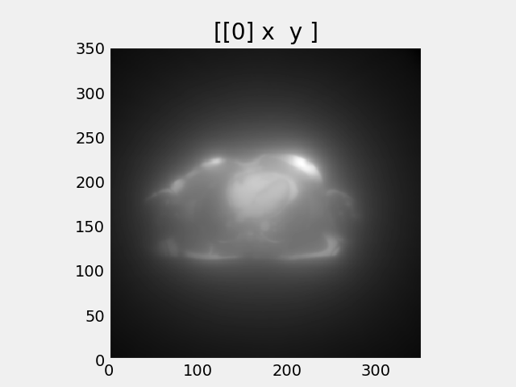

```
<sigpy.plot.ImagePlot at 0x7f513e7a4750>
```

```python
sigpy.plot.ImagePlot(back_no_density_compensation, x=1, y=2)
```

# Now bring the reconstructed image back into cartesian k-space

- if we now take the density-compensated reconstructed image (i.e. the one derived from non-cartesian k-space data) and perform a standard `FFT`, we can get cartesian k-space data
- recall that going from non-cartesian radial k-space data to cartesian k-space data requires a gridding operation that interpolates the radial data onto a cartesian grid. this interpolation does introduce some artifacts, since the data in this new **cartesian** k-space isn't the truly measured data from the coils-- they are the interpolated values onto the cartesian grid.
- also note that radial k-space data does not extend all the radial spokes to the edges of the image, but appears as a circle inscribed inside a rectangle. this is another slight difference to the radial mask in `RefineGAN`.

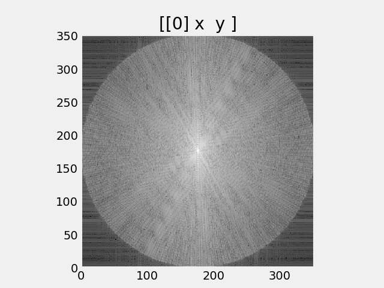

```
<sigpy.plot.ImagePlot at 0x7f513df00690>
```

```python
cartesian_kspace = sigpy.fft(back)

sigpy.plot.ImagePlot(np.log(np.abs(cartesian_kspace)), x=1, y=2)
```

# Finally, we can apply an inverse FFT to get back to image space

- this will not be identical to the original `square_cine` image, since the non-cartesian gridding operations necessarily create new data that was not actually measured, but it should be pretty close

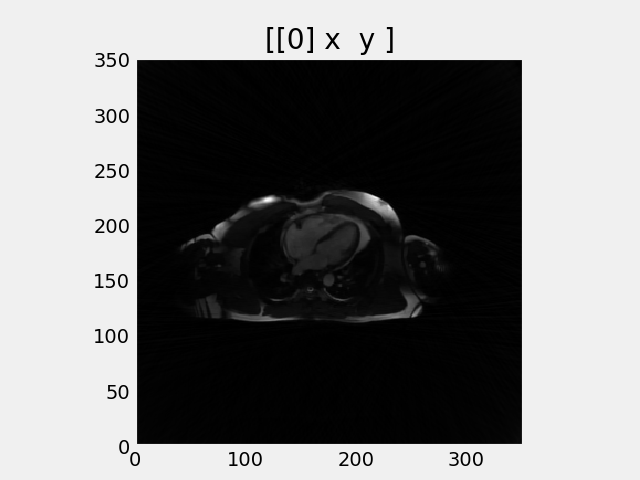

```
<sigpy.plot.ImagePlot at 0x7f513dfb3350>
```

```python
cartesian_image = sigpy.ifft(cartesian_kspace)
sigpy.plot.ImagePlot(cartesian_image, x=1, y=2)
```

# Remarks

- in this notebook, we only worked on a single frame from the cine and treated it as a single-coil acquisition
- the next notebook will cover the case of multi-coil non-cartesian acquisition, with combination of the multi-coil data using `SENSE` type operators along with the coil sensitivity maps that we have calculated and dumped into the `ocmr_intermediate.hdf5` container.
  - we'll also cover a more realistic scenario in which the different frames of the cine have different radial sampling patterns (e.g. different number of radial spokes with a more random mix of angles), as is typical in our cardiac MRI data that has been sorted.